# Data 624 - HA Assignments

Group 1: Andrew Carson, Nathan Cooper, Baron Curtin, Heather Geiger, Alejandro Osborne

2019-02-14

## HW1

### 2.3

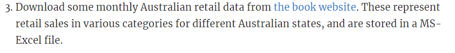

#### a

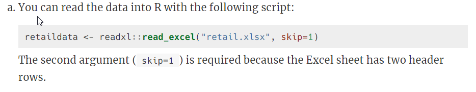

```r
retailData <- readxl::read_excel("./week1/retail.xlsx", skip = 1)
```

#### b

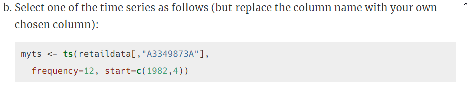

```r
myts <- ts(retailData[, "A3349338X"], frequency = 12, start = c(1982, 4))
```

#### c

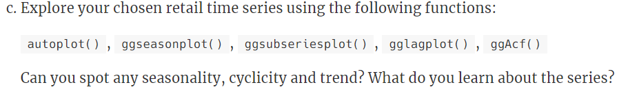

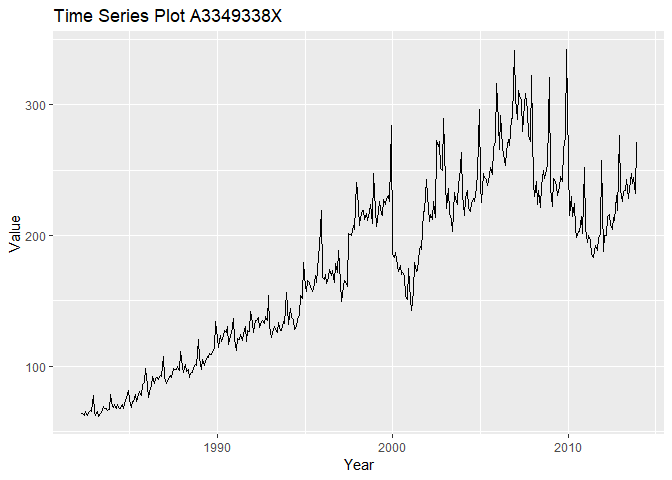

```r
autoplot(myts[, "A3349338X"]) + ggtitle("Time Series Plot A3349338X") + xlab("Year") +
    ylab("Value")
```

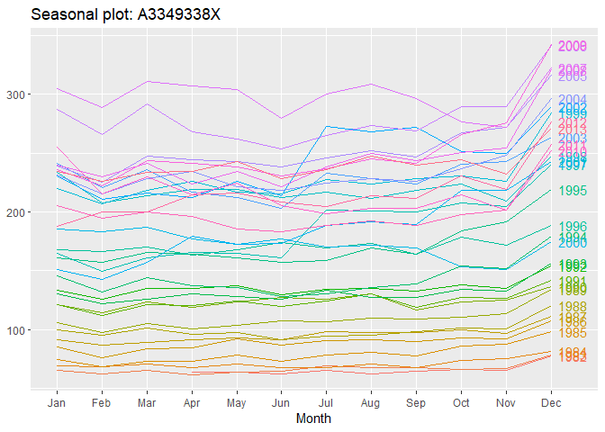

```r
ggseasonplot(myts, year.labels = T) + ggtitle("Seasonal plot: A3349338X")
```

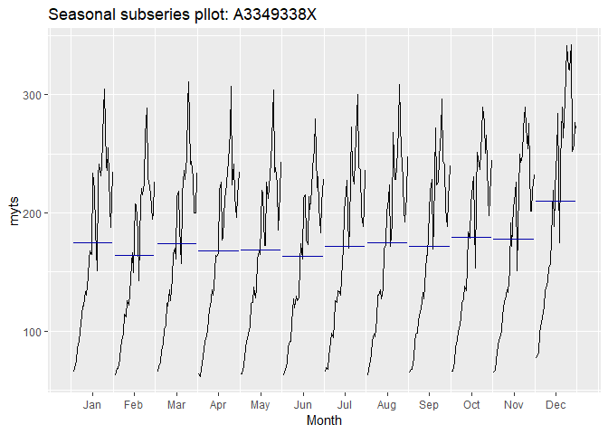

```r
ggsubseriesplot(myts) + ggtitle("Seasonal subseries pllot: A3349338X")
```

From the seasonal plot, we are able to deduce: * Seasonality: there is some clear seasonality that exists among different month, however it is not without minor variation/deviation between the years * December shows a clear uptick while February shows a clear downtick

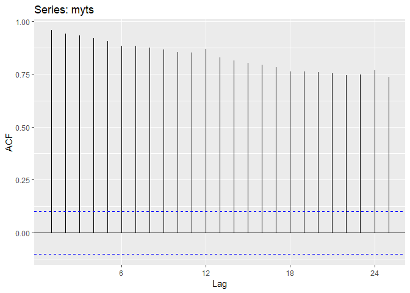

```r
ggAcf(myts)
```

From the Acf plot, we are able to confirm: * Trend: the autocorrelations are slowly decreasing as the lags are increasing

Conclusion: * Trend exists in this time series and is slowly going upwrd * Seasonality appears to exist however there are years that defy seasonality patterns * There does not appear to be any cyclic behavior

### 2.7

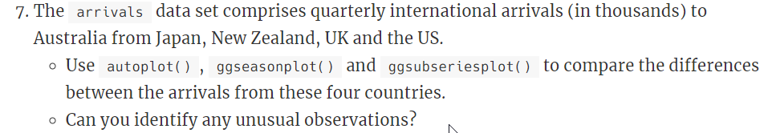

```r
# arrivals <- data('arrivals')
```

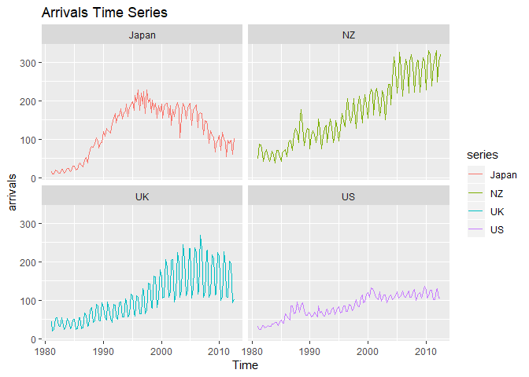

```r
autoplot(arrivals) + ggtitle("Arrivals Time Series") + facet_wrap(~series)
```

Observations: * Japan seems to experience a an upward trend, reach an apex, and then experience a downward trend * NZ, UK, and US all experience upward trends in arrivals albeit to different degrees * UK appears to have the greatest variance in their arrival figures * US has very little deviation in their arrival trend * NZ has more fluctuation than US, but less than UK in their arrivals * US on average has the lowest amount of arrivals

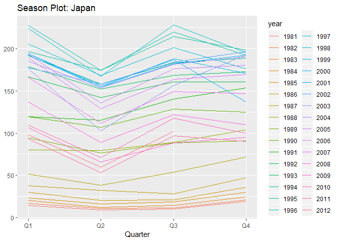

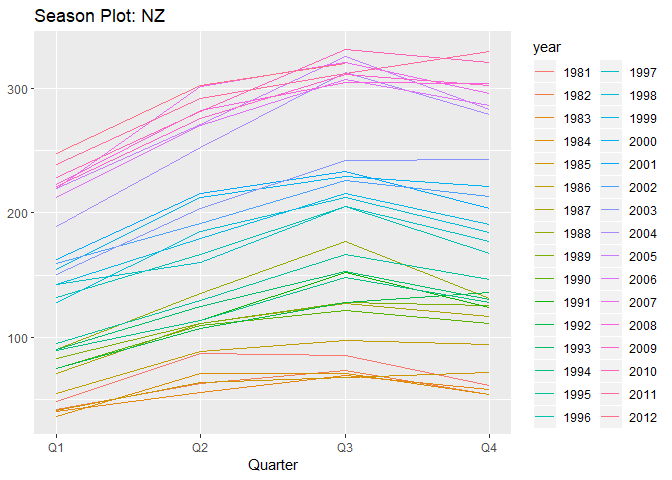

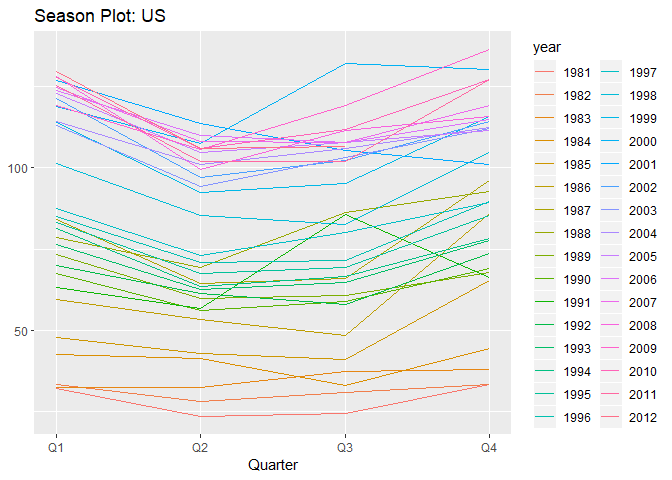

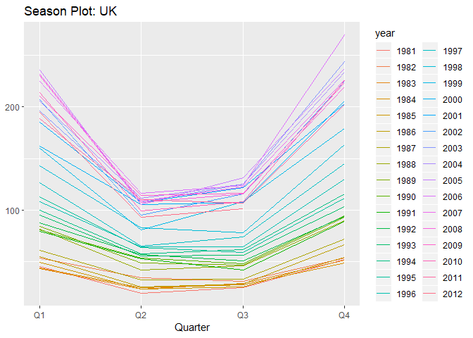

```r
genSeasonPlot <- function(country) {
    ggseasonplot(arrivals[, country]) + ggtitle(glue("Season Plot: {country}"))
}

countries <- c("Japan", "NZ", "US", "UK")
countries %>% map(~genSeasonPlot(.x))
```

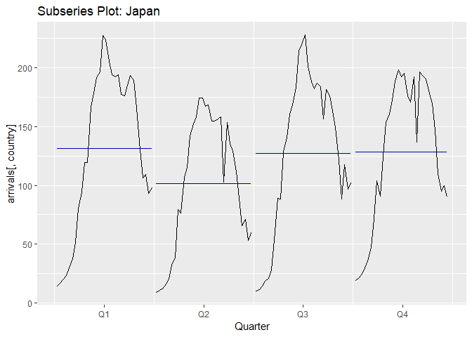

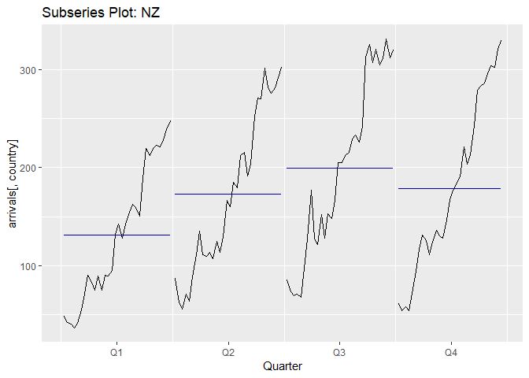

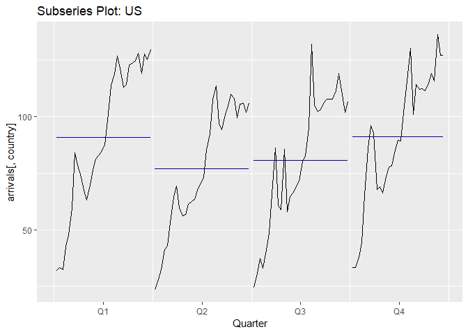

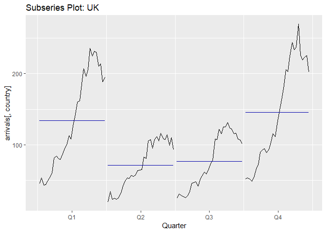

```r
genSubSeasonPlot <- function(country) {
    ggsubseriesplot(arrivals[, country]) + ggtitle(glue("Subseries Plot: {country}"))
}

countries %>% map(~genSubSeasonPlot(.x))
```

Observations: * Japan’s mean stays relatively flat across the quarters outside of Q2 * US also remains relatively consistent and further backs up the lack of deviation point made earlier * UK experiences the most arrivals in Q1 and A4

### 2.10

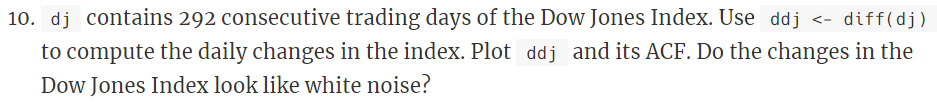

```r
data("dj")
ddj <- diff(dj)
```

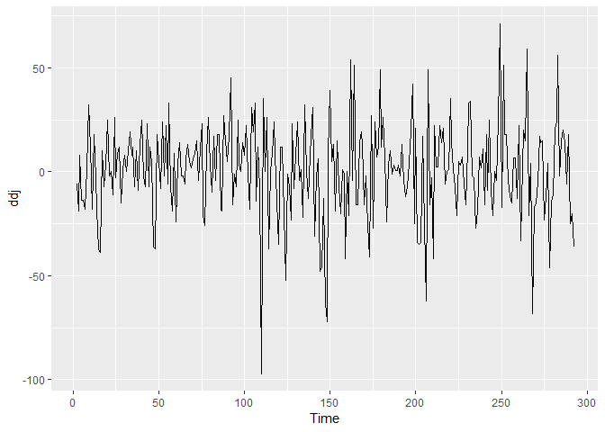

```r
autoplot(ddj)
```

The autoplot appears to show random variation with peaks and valleys

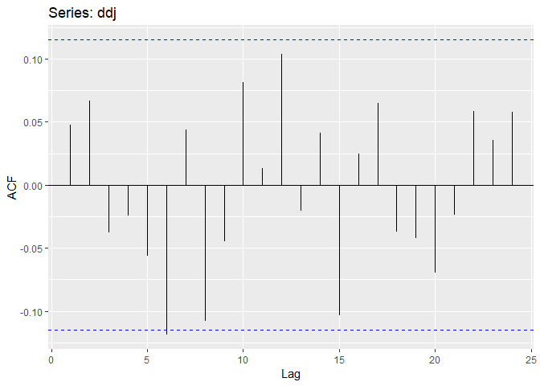

```r
ggAcf(ddj)
```

The changes in the Dow Jones Index do appear to be white noise as the the autocorrelations are very close to zero

### 3.1

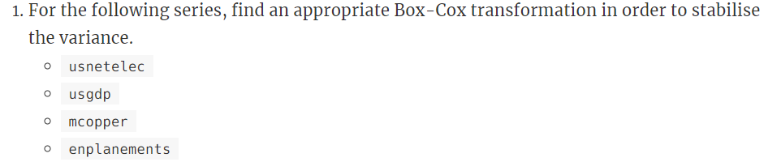

#### usnetelec

```r
data("usnetelec")
lambda <- BoxCox.lambda(usnetelec) %>% print()
```

```
## [1] 0.5167714
```

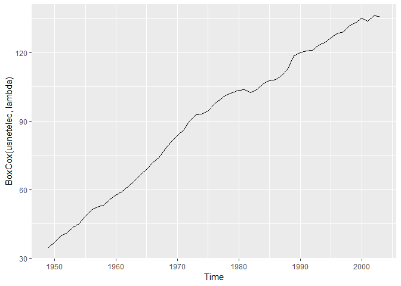

```r
autoplot(BoxCox(usnetelec, lambda))
```

#### usgdp

```r
data("usgdp")

lambda <- BoxCox.lambda(usgdp) %>% print()
```

```
## [1] 0.366352
```

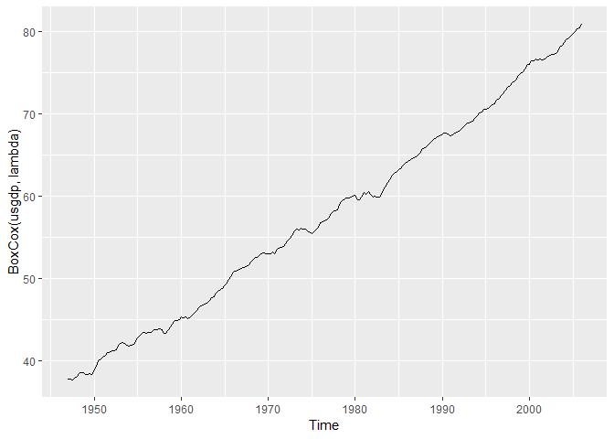

```r
autoplot(BoxCox(usgdp, lambda))
```

#### mcopper

```r
data("mcopper")

lambda <- BoxCox.lambda(mcopper) %>% print()
```

```
## [1] 0.1919047
```

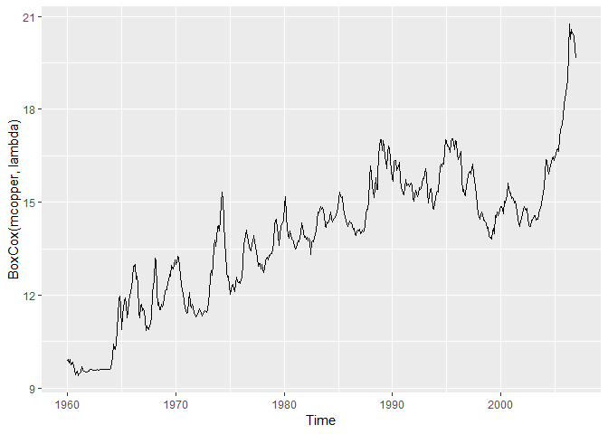

```r
autoplot(BoxCox(mcopper, lambda))
```

#### enplanements

```r
data("enplanements")

lambda <- BoxCox.lambda(enplanements) %>% print()
```

```
## [1] -0.2269461
```

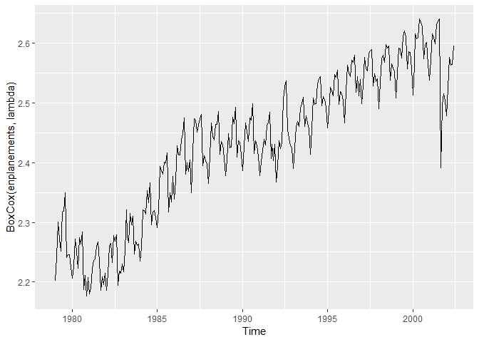

```r
autoplot(BoxCox(enplanements, lambda))
```

### 3.8

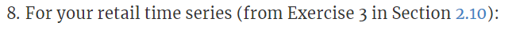

#### a

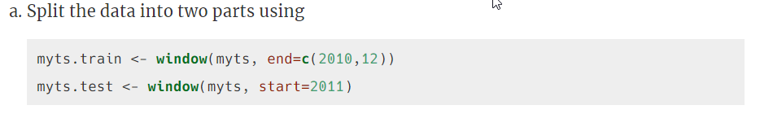

```r
myts.train <- window(myts, end = c(2010, 12))
myts.test <- window(myts, start = 2011)
```

#### b

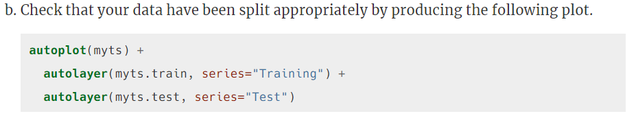

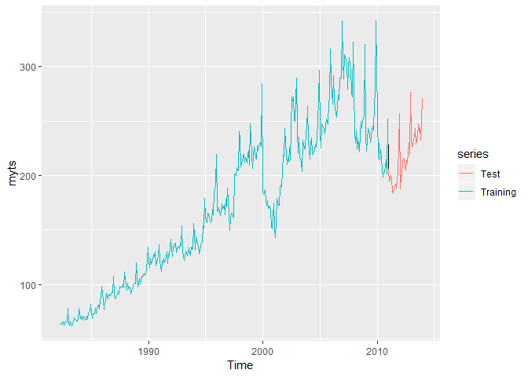

```r
autoplot(myts) + autolayer(myts.train, series = "Training") + autolayer(myts.test,
    series = "Test")
```

The autoplot shows that the data has been correctly split with the latter part of the data reservered for testing

#### c

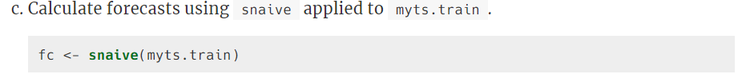

```r
fc <- snaive(myts.train)

print(fc)
```

```
##          Point Forecast    Lo 80    Hi 80    Lo 95    Hi 95
## Jan 2011          255.4 219.8378 290.9622 201.0123 309.7877
## Feb 2011          215.5 179.9378 251.0622 161.1123 269.8877
## Mar 2011          229.6 194.0378 265.1622 175.2123 283.9877
## Apr 2011          214.4 178.8378 249.9622 160.0123 268.7877
## May 2011          224.5 188.9378 260.0622 170.1123 278.8877
## Jun 2011          205.6 170.0378 241.1622 151.2123 259.9877
## Jul 2011          198.7 163.1378 234.2622 144.3123 253.0877
## Aug 2011          203.3 167.7378 238.8622 148.9123 257.6877
## Sep 2011          203.2 167.6378 238.7622 148.8123 257.5877
## Oct 2011          214.4 178.8378 249.9622 160.0123 268.7877
## Nov 2011          201.4 165.8378 236.9622 147.0123 255.7877
## Dec 2011          251.8 216.2378 287.3622 197.4123 306.1877
## Jan 2012          255.4 205.1074 305.6926 178.4841 332.3159
## Feb 2012          215.5 165.2074 265.7926 138.5841 292.4159
## Mar 2012          229.6 179.3074 279.8926 152.6841 306.5159
## Apr 2012          214.4 164.1074 264.6926 137.4841 291.3159
## May 2012          224.5 174.2074 274.7926 147.5841 301.4159
## Jun 2012          205.6 155.3074 255.8926 128.6841 282.5159
## Jul 2012          198.7 148.4074 248.9926 121.7841 275.6159
## Aug 2012          203.3 153.0074 253.5926 126.3841 280.2159
## Sep 2012          203.2 152.9074 253.4926 126.2841 280.1159
## Oct 2012          214.4 164.1074 264.6926 137.4841 291.3159
## Nov 2012          201.4 151.1074 251.6926 124.4841 278.3159
## Dec 2012          251.8 201.5074 302.0926 174.8841 328.7159
```